# Homework #4

C.J. Laws, Zack Roder, Graham Shank

#### Exercise 2.8

$$x_t = w_t\\
y_t = w_t - \theta w_{t-1} + \mu_t$$

##### Part (a)

For $h=0$:

$$\begin{align}
\gamma_y(t,t) &= \text{cov}(y_t, y_t)\\
&= \text{cov}[(w_t - \theta w_{t-1} + \mu_t), (w_t - \theta w_{t-1} + \mu_t)]\\
&= \sigma_w^2 + \theta^2\sigma_w^2 + \sigma_\mu^2\\
&= (1 + \theta^2)\sigma_w^2 + \sigma_\mu^2
\end{align}$$

For $h=1$:

$$\begin{align}
\gamma_y(t,t+1) &= \text{cov}[(w_t - \theta w_{t-1} + \mu_t), (w_{t+1} - \theta w_t + \mu_{t+1})]\\
&=\theta\sigma_w^2
\end{align}$$

For $h \ge 2$, it is evident that $\gamma_y(h) = 0$. Thus, the ACF is as follows:
$$\begin{align}
\rho_y(h) = \begin{cases} 1 \quad h=0\\ \frac{\theta\sigma_w^2}{(1+\theta^2)\sigma_w^2 + \sigma_\mu^2} \quad h=\pm 1\\ 0 \quad |h| \ge 2\end{cases}
\end{align}$$

##### Part (b)

For $h=0$:
$$\begin{align}
\gamma_{xy}(0) &= \text{cov}[w_t, w_t - \theta w_{t-1} + \mu_t]\\
&= \sigma_w^2
\end{align}$$

For $h=-1$:
$$\begin{align}
\gamma_{xy}(-1) &= \text{cov}[w_{t-1}, w_t - \theta w_{t-1} + \mu_t]\\
&= \text{cov}(w_{t-1}, -\theta w_{t-1})\\
&= -\theta \sigma_w^2
\end{align}$$

We observe that for all $h \ne -1, 0$, $\gamma_{xy} = 0$. Noting that $\gamma_x(0) = \sigma_w^2$, we can find the CCF of $x_t$ and $y_t$:
$$\begin{align}
\rho_{xy}(h) &= \frac{\gamma_{xy}(h)}{\sqrt{\gamma_x(0)\gamma_y(0)}}\\
&= \frac{\gamma_{xy}(h)}{\sqrt{\sigma_w^2((1+\theta^2)\sigma_w^2 + \sigma_{\mu}^2)}}\\
&= \frac{\gamma_{xy}(h)}{\sigma_w\sqrt{\sigma_w^2 + \theta^2\sigma_w^2 + \sigma_{\mu}^2}}
\end{align}$$

Then, for the lag values that we know $\gamma_{xy}(h)$ is not equal to zero, we can summarize the CCF as follows:
$$\begin{align}
\rho_{xy}(h) &= \begin{cases} \frac{\sigma_w}{\sqrt{\sigma_w^2 + \theta^2\sigma_w^2 + \sigma_{\mu}^2}} \quad h=0\\
\frac{-\theta\sigma_w}{\sqrt{\sigma_w^2 + \theta^2\sigma_w^2 + \sigma_{\mu}^2}} \quad h=-1
\end{cases}
\end{align}$$

##### Part (c)

Since both $x_t$ and $y_t$ are clearly stationary and their cross-covariance function is a function only of lag $h$, we can confirm that the two series are jointly stationary.

#### Exercise 2.9

First, we find the mean value function:
$$\begin{align}
E(x_t) &= E(w_tw_{t-1})\\
&= E(w_t)E(w_{t-1}) \quad \text{Note: since $w_t$ is indep. of $w_{t-1}$}\\
&= 0 \cdot 0\\
&= 0
\end{align}$$

Then, we find the autocovariance function, first for lag 0 ($h=0$):
$$\begin{align}
\gamma_x(0) &= \text{cov}(x_t, x_t)\\
&= E[(w_tw_{t-1} - 0)(w_tw_{t-1} - 0)]\\
&= E[w_t^2w_{t-1}^2]\\
&= E(w_t^2)E(w_{t-1}^2)\\
&= \text{Var}(w_t)\text{Var}(w_{t-1})\\
&= \sigma_w^2\sigma_w^2\\
&= \sigma_w^4
\end{align}$$

For $h=1$:
$$\begin{align}
\gamma_x(1) &= \text{cov}(x_t, x_{t+1})\\
&= E[(w_tw_{t-1} - 0)(w_{t+1}w_{t} - 0)] \\
&= E(w_t^2)E(w_{t-1})E(w_{t+1})\\
&= \sigma_w^2 \cdot 0 \cdot 0 \\
&= 0
\end{align}$$

Clearly, $\gamma_x(h) = 0$ for all $h \ne 0$. In summary, autocovariance function is:
$$\begin{align}
\gamma_x(h) = \begin{cases} \sigma_w^4 \quad h = 0\\ 0 \quad h \ne 0 \end{cases}
\end{align}$$

Since the mean value function is constant for all $t$ and the autocovariance function only depends on time in terms of lag, we can conclude that $x_t$ is stationary.

#### Exercise 2.10

##### Part (a)

The mean function is as follows:
$$\begin{align}
E(x_t) &= E(\mu + w_t + \theta w_{t-1})\\
&= E(\mu) + E(w_t) + \theta E(w_{t-1}) \\
&= \mu + 0 + \theta(0)\\
&= \mu
\end{align}$$

##### Part (b)

For $h=0$:
$$\begin{align}
\gamma_x(0) &= \text{cov}[(\mu + w_t + \theta w_{t-1}),(\mu + w_t + \theta w_{t-1})]\\
&= \text{cov}(\mu, \mu) + \text{cov}(w_t, w_t) + \text{cov}(\theta w_{t-1}, \theta w_{t-1})\\
&= 0 + \sigma_w^2 + \theta^2\sigma_w^2 \\
&= \sigma_w^2(1+\theta^2)
\end{align}$$

For $h = \pm 1$:
$$\begin{align}
\gamma_x(\pm 1) &= \text{cov}[(\mu + w_t + \theta w_{t-1}), (\mu + w_{t+1} + \theta w_t)]\\
&= \text{cov}(\mu, \mu) + \theta \text{cov}(w_t, w_t) \\
&= \sigma_w^2 \theta
\end{align}$$
For all $h \not\in \{-1, 0, 1\}$, it is clear that the autocovariance will be $0$, since $w_t$ is independent from $w_s$ for all $s,t$ such that $s \ne t$.

##### Part (c)

$\forall \theta \in \mathbb{R}$, it is clear that $E(x_t) = \mu$, since this value is unaffected by $\theta$. Likewise, for any value of $\theta$, the autocovariance function still only depends on $s,t$ in terms of their difference (lag). The value of the autocovariance changes with $\theta$, but the value of $\theta$ does not alter the autocovariance’s relationship with $s,t$. Hence, $x_t$ is stationary regardless of the value of $\theta$.

##### Part (d)

Since the autocovariance function is $0$ for all values of $h$ not $0$ or $\pm 1$,
$$\begin{align}
\text{var}(\bar{x}) &= \frac{1}{n}\sum_{h=-n}^2\left(1 - \frac{|h|}{n}\right)\gamma_x(h)\\
&= \frac{1}{n} \left[\gamma_x(0) + \left(1 - \frac{1}{n} \right)\gamma_x(1) + \left(1 - \frac{1}{n} \right)\gamma_x(-1) \right]\\
&= \frac{1}{n} \left[\gamma_x(0) + \frac{2(n-1)}{n}\gamma_x(1) \right]
\end{align}$$

###### (i) For $\theta = 0$:

$$\begin{align}
\text{Var}(\bar{x}) &= \frac{1}{n}\left[ \sigma_w^2 + 0 \right]\\
&= \frac{\sigma_w^2}{n}
\end{align}$$

###### (ii) For $\theta = 1$:

$$\begin{align}
\text{Var}(\bar{x}) &= \frac{1}{n}\left[ 2\sigma_w^2 + \frac{2(n-1)}{n}\sigma_w^2 \right]\\
&= \frac{\sigma_w^2}{n}\left[4 - \frac{2}{n} \right]
\end{align}$$

###### (iii) For $\theta = -1$:

$$\begin{align}
\text{Var}(\bar{x}) &= \frac{1}{n}\left[2\sigma_w^2 + \frac{2(n-1)}{n}(-\sigma_w^2) \right]\\
&= \frac{\sigma_w^2}{n} \cdot \frac{2}{n}
\end{align}$$

##### Part (e)

Intuitively, a larger sample size improves the accuracy in the estimate of mean $\mu$. This can be seen in the three results derived in part (d); we see that $\text{Var}(\bar{x})$ when $\theta = 0$, remains unchanged, while
$$\text{Var}(\bar{x}) = \frac{4\sigma_w^2}{n} \quad \theta=1 \\
\text{Var}(\bar{x}) = \frac{1}{n}\left(2\sigma_w^2 - 2\sigma_w^2 \right) = 0 \quad \theta = -1$$

#### Exercise 2.14

##### Part (a)

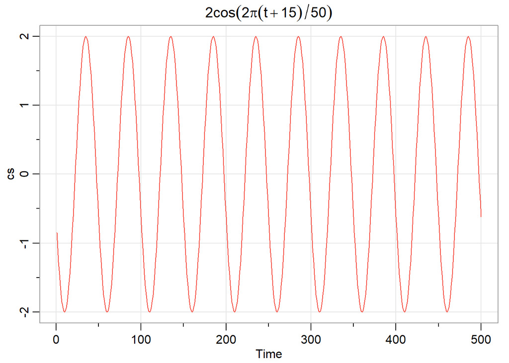

```r
t = 1:500
cs = 2*cos(2*pi*(t+15)/50)
w = rnorm (500)
tsplot(cs, col = 2, main = expression(2*cos(2*pi*(t+15)/50)))
```

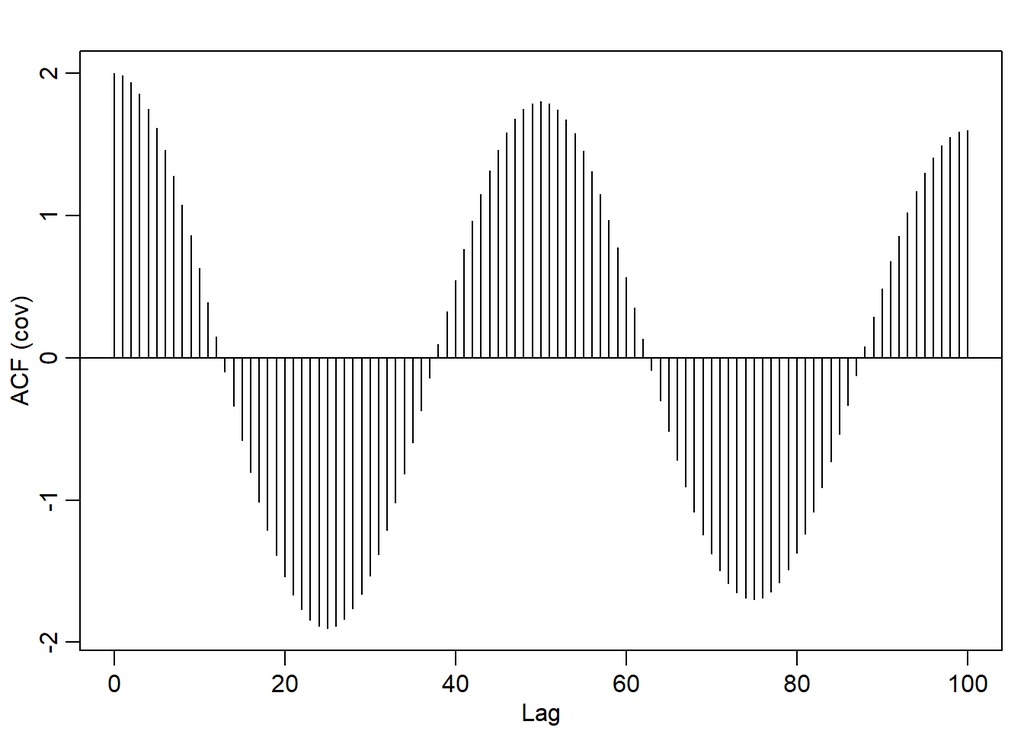

```r
acf(cs, lag.max = 100, type = "covariance")
```

##### Part (b)

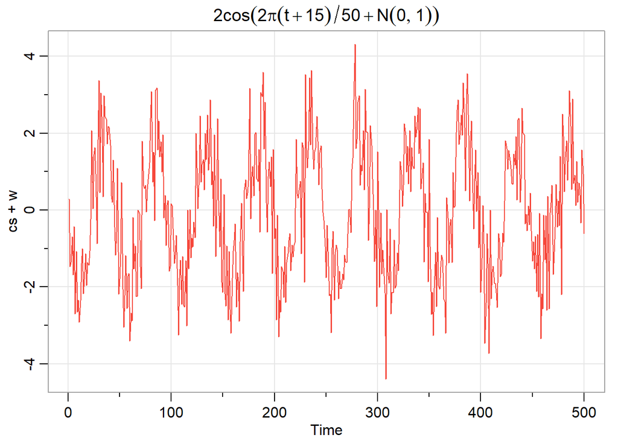

```r
t = 1:500
cs = 2*cos(2*pi*(t+15)/50)
w = rnorm (500)
tsplot(cs + w, col = 2, main=expression(2*cos(2*pi*(t+15)/50 + N(0,1))))
```

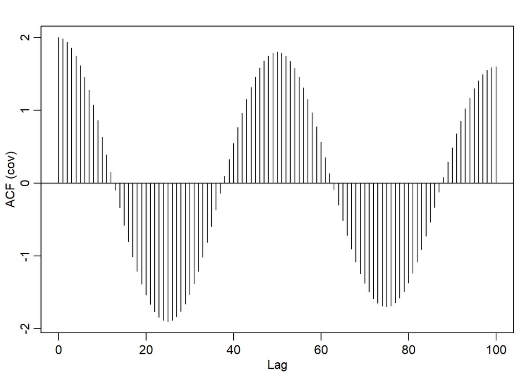

```r
acf(cs, lag.max = 100, type = "covariance")
```

#### Part (c)

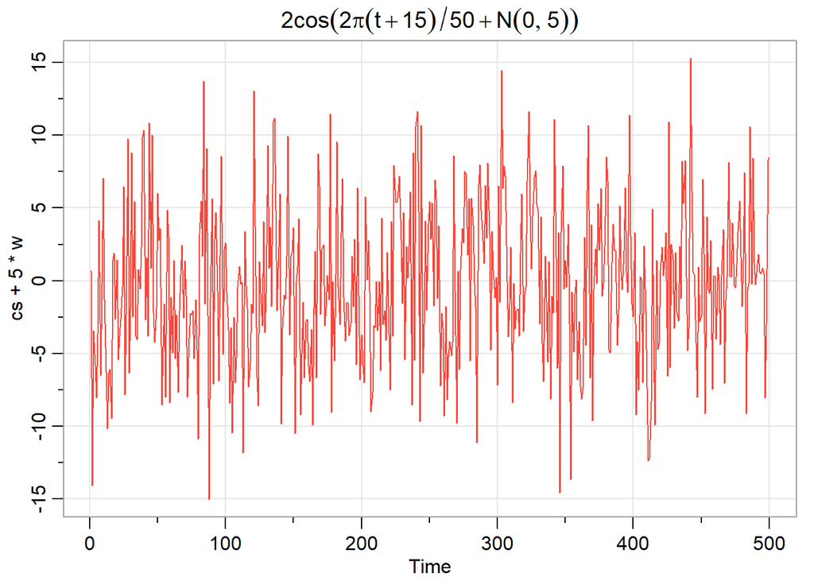

```r
t = 1:500
cs = 2*cos(2*pi*(t+15)/50)
w = rnorm (500)
tsplot(cs + 5*w, col = 2, main=expression(2*cos(2*pi*(t+15)/50 + N(0,5))))
```

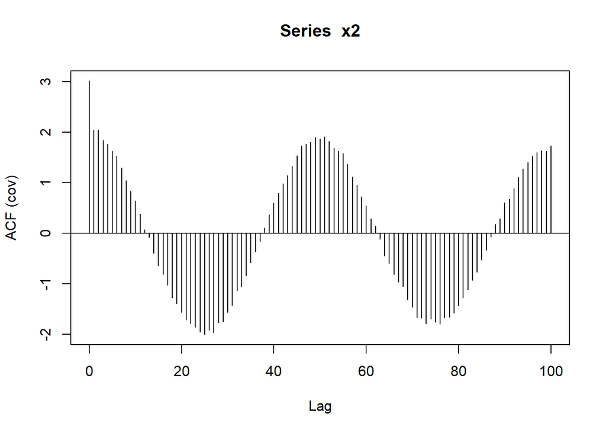

```r
s2 = 2*cos(2*pi*((1:500 +15)/(50)))
x2 = ts(s2 + rnorm(500))
acf(x2, lag.max = 100, type = "covariance")
```